# Course Project Practical Machine Learning

## Synopsis

This prediction project was done on date and time: 2015-01-21 20:28:56 and version used: R version 3.1.2 (2014-10-31) by Lucho Farje. Using data which has been generated by devices such as Nike, FuelBand, FitBit and Jawbone Up about personal activity and self movements which were attached in their body of different persons. The goal using this dataset is to find patterns using machine learning to build a prediction model. The data to be used is coming from accelerometers on the belt, forearm, arm and dumbell of 6 participants which were asked to perform barbell lifts correctly and incorrectly in five different ways.

## Setting Global Environment

This prediction analysis needs some packages in order to be processed. The **caret** package is important for this prediction model as well as another support packages which makes the entire analysis process much easier to perform. An important hint in this process is to highlight that in this step it's being initialized the seed variable and creating a clusters of cores for this computer.

```r
library(caret)
library(randomForest)
library(rattle)
library(pROC)
library(rpart)

library(parallel)
library(doParallel)
```

```r
library(ggplot2)
library(reshape2)

library(xtable)
#using parallel clusters for the cores of this machine/server
cluster.cores<-makeCluster(detectCores()-1)
registerDoParallel(cluster.cores)
#Initialize seed
day.of.begin.project<-"2015-01-16"
seed.number<-as.numeric(as.Date(day.of.begin.project))
set.seed(seed.number)
```

## Download and Load Datasets

In this step the data will be downloaded and loaded into variables in order to be filtered and pre-processed for applying the prediction model.

```r
if (!file.exists("./data/pml-testing.csv"))
  { download.file("https://d396qusza40orc.cloudfront.net/predmachlearn/pml-testing.csv", "./data/pml-testing.csv") }

if (!file.exists("./data/pml-training.csv"))
  { download.file("https://d396qusza40orc.cloudfront.net/predmachlearn/pml-training.csv", "./data/pml-training.csv") }

data.training<-read.csv("./data/pml-training.csv", na.strings=c("NA",""), stringsAsFactors=FALSE)
data.testing<-read.csv("./data/pml-testing.csv", na.strings=c("NA",""), stringsAsFactors=FALSE)
```

## Data Pre-Processing

It's important to apply a function in order to filter the features which might contain any missing data, in other words, there are many variables in the dataset and it's imperative to remove any with NA's values or empty strings. It's also being removed all columns that are not included in the prediction model. It's important to point that it's not necessary to **create a data partition** for these datasets because there are already two set of files one for training and one for testing. Finally, it's also considered to show a histogram for each type of accelerometer used in differents parts of the body. This is done by a function and help of **ggplot2** packages which was previously loaded.

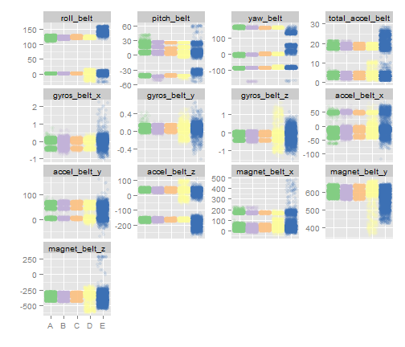

```r
filteringdata<-function(dataset)
  {
  keepdata<-!sapply(dataset, function(x) any(is.na(x)))
  dataset<-dataset[,keepdata]
  keepdata<-!sapply(dataset, function(x) any(x==""))
  dataset<-dataset[,keepdata]

  removingcol<-c("X", "user_name", "raw_timestamp_part_1", "raw_timestamp_part_2", "cvtd_timestamp", "new_window", "num_window")
  doremove<-which(colnames(dataset) %in% removingcol)
  dataset<-dataset[,-doremove]
  return(dataset)
  }
data.training<-filteringdata(data.training)
data.training$classe<-factor(data.training$classe)
data.testing<-filteringdata(data.testing)

#head(data.training)
#head(data.testing)

histogramxGroup <- function (data, regex) {
  col <- grep(regex, names(data))
  col <- c(col, which(names(data) == "classe"))
  n <- nrow(data)
  DMelted <- melt(data[, col, ][ , ], id.vars=c("classe"))
  ggplot(DMelted, aes(x=classe, y=value)) +
    #geom_violin(aes(color=classe, fill=classe), alpha=1/2) +
    geom_jitter(aes(color=classe, fill=classe), alpha=1/10) +
    facet_wrap(~ variable, scale="free_y") +
    scale_color_brewer(type="qual", palette=1) +
    scale_fill_brewer(type="qual", palette=1) +
    labs(x="", y="") +
    theme(legend.position="none")
}

histogramxGroup(data.training,"belt")
```

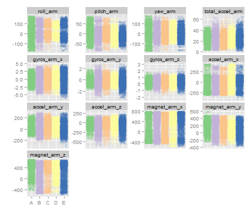

```r
histogramxGroup(data.training,"[^(fore)]arm")
```

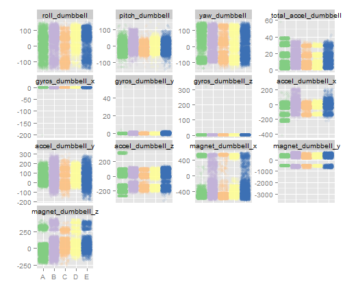

```r
histogramxGroup(data.training,"dumbbell")
```

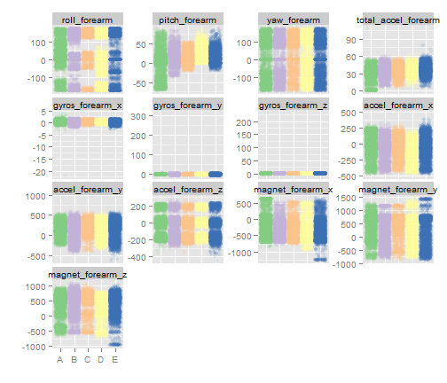

```r
histogramxGroup(data.training,"forearm")
```

## Train and Evaluate The Prediction Model

For training the dataset will be used **random forest** and **SVM (radial kernel)** algorithms. The goal is to get an accuracy of greather than 0.930. For processing the dataset faster, it will be used parallel clusters which were defined in the first section and will be stopped as a final step in this section because of size of the data. For testing the model it won't be needed to parallelize cores. The cross-validation is being done 5 times with help of the parameter number in the **trainControl** function. It's also shown a cross-validation accuracy table for these two models where the model which uses **random forest** reach more higher accuracy than other model. The prediction models are applied to the **hat** variables and then the confussion Matrix is generated. Finally, it will be calculated variable importance for each model and then it's written that **randon forest** algorithm gives a better accuracy of **99,57%**

```r
controlPM<-trainControl(method="cv", number=5, allowParallel=TRUE, verboseIter=TRUE)
model1<-train(classe~., data=data.training,method="rf",trControl=controlPM)
model2<-train(classe~., data=data.training,method="svmRadial",trControl=controlPM)
```

```r
accuracy.table<-data.frame(Model=c("Random Forest", "SVM (radial)"), Accuracy=c(round(max(head(model1$results)$Accuracy),3), round(max(head(model2$results)$Accuracy),3)))

#require(rpart.plot)
#build.dt <- rpart(classe ~ ., data=data.training, method="class")
#build.dt$Accuracy
#fancyRpartPlot(build.dt)

accuracy.table
```

```
##           Model Accuracy
## 1 Random Forest    0.995
## 2  SVM (radial)    0.934
```

```r
hatm1<-predict(model1, data.training)
hatm2<-predict(model2, data.training)

#hatm1tmp<-predict(model1, data.training, type="class") #either raw or prob

confusionMatrix(hatm1, data.training$classe)
```

```
## Confusion Matrix and Statistics
##
##           Reference
## Prediction    A    B    C    D    E
##          A 5580    0    0    0    0
##          B    0 3797    0    0    0
##          C    0    0 3422    0    0
##          D    0    0    0 3216    0
##          E    0    0    0    0 3607
##
## Overall Statistics
##
##                Accuracy : 1
##                  95% CI : (1, 1)
##     No Information Rate : 0.284
##     P-Value [Acc > NIR] : <2e-16
##
##                   Kappa : 1
##  Mcnemar's Test P-Value : NA
##
## Statistics by Class:
##
##                      Class: A Class: B Class: C Class: D Class: E
## Sensitivity             1.000    1.000    1.000    1.000    1.000
## Specificity             1.000    1.000    1.000    1.000    1.000
## Pos Pred Value          1.000    1.000    1.000    1.000    1.000
## Neg Pred Value          1.000    1.000    1.000    1.000    1.000
## Prevalence              0.284    0.194    0.174    0.164    0.184
## Detection Rate          0.284    0.194    0.174    0.164    0.184
## Detection Prevalence    0.284    0.194    0.174    0.164    0.184
## Balanced Accuracy       1.000    1.000    1.000    1.000    1.000
```

```r
confusionMatrix(hatm2, data.training$classe)
```

```
## Confusion Matrix and Statistics
##
##           Reference
## Prediction    A    B    C    D    E
##          A 5553  292    8    5    0
##          B   14 3412  109    0   19
##          C   12   85 3276  301  105
##          D    0    2   26 2907   83
##          E    1    6    3    3 3400
##
## Overall Statistics
##
##                Accuracy : 0.945
##                  95% CI : (0.942, 0.948)
##     No Information Rate : 0.284
##     P-Value [Acc > NIR] : <2e-16
##
##                   Kappa : 0.931
##  Mcnemar's Test P-Value : <2e-16
##
## Statistics by Class:
##
##                      Class: A Class: B Class: C Class: D Class: E
## Sensitivity             0.995    0.899    0.957    0.904    0.943
## Specificity             0.978    0.991    0.969    0.993    0.999
## Pos Pred Value          0.948    0.960    0.867    0.963    0.996
## Neg Pred Value          0.998    0.976    0.991    0.981    0.987
## Prevalence              0.284    0.194    0.174    0.164    0.184
## Detection Rate          0.283    0.174    0.167    0.148    0.173
## Detection Prevalence    0.299    0.181    0.193    0.154    0.174
## Balanced Accuracy       0.987    0.945    0.963    0.949    0.971
```

```r
varImp(model1)
```

```
## rf variable importance
##
##   only 20 most important variables shown (out of 52)
##
##                      Overall
## roll_belt             100.00
## pitch_forearm          59.39
## yaw_belt               54.48
## pitch_belt             44.44
## magnet_dumbbell_z      42.74
## magnet_dumbbell_y      42.31
## roll_forearm           41.79
## accel_dumbbell_y       20.25
## roll_dumbbell          16.96
## accel_forearm_x        16.85
## magnet_dumbbell_x      16.67
## magnet_belt_z          14.15
## magnet_forearm_z       13.97
## accel_dumbbell_z       13.97
## total_accel_dumbbell   13.94
## accel_belt_z           12.57
## magnet_belt_y          12.34
## gyros_belt_z           11.38
## yaw_arm                10.86
## magnet_belt_x           9.58
```

```r
require(pROC)
varImp(model2)
```

```
## ROC curve variable importance
##
##   variables are sorted by maximum importance across the classes
##   only 20 most important variables shown (out of 52)
##
##                       A    B    C     D    E
## pitch_forearm     100.0 64.1 71.8 100.0 68.3
## roll_dumbbell      52.9 63.7 84.4  84.4 58.8
## accel_forearm_x    81.7 51.2 64.0  81.7 47.5
## magnet_arm_x       78.8 54.6 56.5  78.8 66.1
## magnet_arm_y       77.3 40.7 54.9  77.3 68.5
## accel_arm_x        73.9 52.4 48.9  73.9 62.7
## pitch_dumbbell     54.3 72.2 72.2  62.5 48.2
## magnet_forearm_x   72.0 51.4 40.8  72.0 43.9
## magnet_belt_y      68.4 61.3 62.7  63.2 68.4
## magnet_dumbbell_y  47.9 66.4 66.4  48.5 53.8
## magnet_dumbbell_x  66.4 66.4 65.6  52.0 53.2
## accel_dumbbell_x   58.2 58.6 58.6  49.1 41.4
## magnet_dumbbell_z  57.7 26.1 57.7  38.7 55.4
## magnet_arm_z       53.9 53.9 38.7  41.9 50.9
## magnet_belt_z      52.1 50.9 50.7  52.5 52.5
## pitch_arm          50.6 29.0 39.1  44.0 50.6
## roll_belt          46.4 41.6 43.4  49.0 49.0
## magnet_forearm_y   39.4 26.9 46.8  46.8 37.1
## accel_dumbbell_z   44.2 44.2 42.1  23.9 31.7
## yaw_dumbbell       21.7 43.1 43.1  20.6 29.7
```

```r
model1$finalModel
```

```
##
## Call:
##  randomForest(x = x, y = y, mtry = param$mtry)
##                Type of random forest: classification
##                      Number of trees: 500
## No. of variables tried at each split: 27
##
##         OOB estimate of  error rate: 0.43%
## Confusion matrix:
##      A    B    C    D    E class.error
## A 5575    3    1    0    1   0.0008961
## B   22 3770    5    0    0   0.0071109
## C    0    9 3404    9    0   0.0052601
## D    0    0   21 3193    2   0.0071517
## E    0    0    6    5 3596   0.0030496
```

```r
model2$finalModel
```

```
## Support Vector Machine object of class "ksvm"
##
## SV type: C-svc  (classification)
##  parameter : cost C = 1
##
## Gaussian Radial Basis kernel function.
##  Hyperparameter : sigma =  0.0140016384731008
##
## Number of Support Vectors : 8901
##
## Objective Function Value : -1363 -940.1 -844.4 -478.1 -1287 -652 -863.2 -1314 -878 -723.2
## Training error : 0.054734
```

```r
stopCluster(cluster.cores)
```

## Applying Prediction Mode On Data Test

Once the prediction model has been calculated so it's time to apply it on the test data set.

```r
hatTD<-predict(model1, data.testing)
#confusionMatrix(hatTD, data.test$classe)
data.testing<-cbind(hatTD, data.testing)
subset(data.testing, select=names(data.testing)[grep("belt|[^(fore)]arm|dumbbell|forearm", names(data.testing), invert=TRUE)])
```

```
##    hatTD problem_id
## 1      B          1
## 2      A          2
## 3      B          3
## 4      A          4
## 5      A          5
## 6      E          6
## 7      D          7
## 8      B          8
## 9      A          9
## 10     A         10
## 11     B         11
## 12     C         12
## 13     B         13
## 14     A         14
## 15     E         15
## 16     E         16
## 17     A         17
## 18     B         18
## 19     B         19
## 20     B         20
```

## Submission results to Coursera

The last step is to generate files for each row/case of the test data set. It's being used a coursera code to achieve that.

```r
pml_write_files = function(x){
  n = length(x)
  for(i in 1:n){
    filename = paste0("./answers/problem_id_",i,".txt")
    write.table(x[i],file=filename,quote=FALSE,row.names=FALSE,col.names=FALSE)
  }
}
pml_write_files(hatTD)
```